# A summary of the tweets generated at Botany 2021 (#Botany2021)

E.J. Rollinson

## About this document

This document was produced by [Emily J. Rollinson](http://rollinsonecology.com) ([@ejrollinson](https://twitter.com/ejrollinson) on Twitter).

The code generating this document was originally developed by [Francois Michonneau](https://github.com/fmichonneau) ([@fmic_](https://twitter.com/fmic_) on Twitter) for the 2015 Evolution meeting and can be found [here](https://github.com/fmichonneau/evol2015-tweets).

I originally adapted this code for the 2015 Ecological Society of America meeting (#ESA100) in Baltimore, MD, and have since reproduced it for [a series of ESA and Botany meetings](https://erollinson.github.io/). I modified it in 2020 to use the rtweet package instead of twitteR to aggregate tweets, updated the code used to generate the wordcloud, and modified the formatting of the plots. In 2021, I updated the code to embed top tweets using tweetrmd.

Tweets using the hashtag #Botany2021 were aggregated from Twitter using the R package [rtweet](https://cran.r-project.org/web/packages/rtweet/index.html) and the Twitter API. The summary statistics are static as of 09:00 AM EDT 7/24/2021 (additional tweets, retweets, and likes after that point are not included in the summary, although embedded tweets are “live” and up-to-date).

This document was generated using RMarkdown, and the source is [available on GitHub](https://github.com/erollinson/erollinson.github.io).

This document (and associated code) is released under a CC0 license.

## Basic summary

Of the 7870 tweets tagged #Botany2021 between 2021-07-18 and 2021-07-24:

| Description | n |
| --- | --- |
| Total of original tweets (no retweets): | 1933 |
| Number of users who tweeted (including retweeting): | 2091 |
| Number of users who tweeted (no retweets): | 395 |

## Top tweeters

Only for original tweets (retweets excluded)

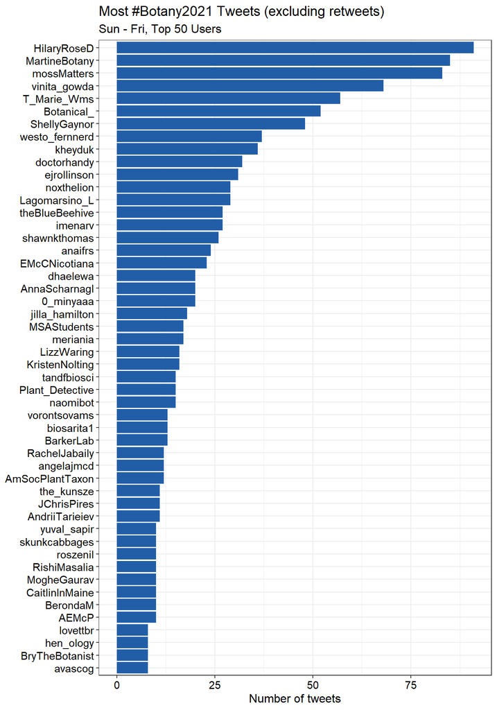

All generated tweets (including retweets)

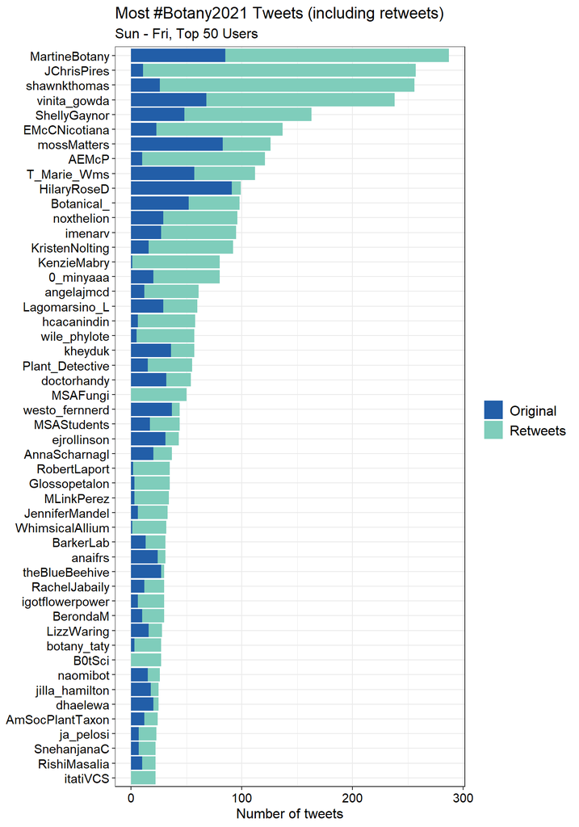

## The 5 most liked tweets

> Hi. When we say things like "first described" or "first collected" what we usually mean is "by white colonizers." By not acknowledging that, we erase indigenous knowledge. [#decolonizeSTEM](https://twitter.com/hashtag/decolonizeSTEM?src=hash&ref_src=twsrc%5Etfw) [#botany2021](https://twitter.com/hashtag/botany2021?src=hash&ref_src=twsrc%5Etfw)

> — Dr. Karolina Heyduk (@kheyduk) [July 21, 2021](https://twitter.com/kheyduk/status/1417883843156058119?ref_src=twsrc%5Etfw)

> hey [#botany2021](https://twitter.com/hashtag/botany2021?src=hash&ref_src=twsrc%5Etfw) friends, come check out my poster today for extremely stale memes! sneak peak below. [pic.twitter.com/LXg50fTJoR](https://t.co/LXg50fTJoR)

> — Kasey Khanh Pham (@KaseyKPham) [July 19, 2021](https://twitter.com/KaseyKPham/status/1417223673870798861?ref_src=twsrc%5Etfw)

> Hey, PIs in STEM: your [#LGBTQIA](https://twitter.com/hashtag/LGBTQIA?src=hash&ref_src=twsrc%5Etfw)+ students are not okay.  
> Last night, the [#Botany2021](https://twitter.com/hashtag/Botany2021?src=hash&ref_src=twsrc%5Etfw) [#LGBTQ](https://twitter.com/hashtag/LGBTQ?src=hash&ref_src=twsrc%5Etfw) Challenges and Experiences discussion room was filled with students and they had a lot to say. (1/7)[#IAmABotanist](https://twitter.com/hashtag/IAmABotanist?src=hash&ref_src=twsrc%5Etfw) [#QueerInSTEM](https://twitter.com/hashtag/QueerInSTEM?src=hash&ref_src=twsrc%5Etfw) [#DiversifySTEM](https://twitter.com/hashtag/DiversifySTEM?src=hash&ref_src=twsrc%5Etfw)

> — Hilary Rose Dawson (@HilaryRoseD) [July 21, 2021](https://twitter.com/HilaryRoseD/status/1417949147080974337?ref_src=twsrc%5Etfw)

> Hey [#Botany2021](https://twitter.com/hashtag/Botany2021?src=hash&ref_src=twsrc%5Etfw)! I'm recruiting multiple (funded!💰) grad students for Fall 2022. MS and Phd.  
> The projects will revolve around the mechanisms behind and impacts of photosynthetic [#acclimation](https://twitter.com/hashtag/acclimation?src=hash&ref_src=twsrc%5Etfw) to [#GlobalChange](https://twitter.com/hashtag/GlobalChange?src=hash&ref_src=twsrc%5Etfw) 🌿🌎  
> If you or someone you know are interested, please reach out!

> — Nick Smith (@nick_greg_smith) [July 19, 2021](https://twitter.com/nick_greg_smith/status/1417155870119579650?ref_src=twsrc%5Etfw)

> Oh my goodness I received the Katherine Esau Award for my talk about Aquilegia spur development at [#Botany2021](https://twitter.com/hashtag/Botany2021?src=hash&ref_src=twsrc%5Etfw)! Thank you thank you [@Botanical_](https://twitter.com/Botanical_?ref_src=twsrc%5Etfw) ! Especially proud to be joining my lab twin [@0_minyaaa](https://twitter.com/0_minyaaa?ref_src=twsrc%5Etfw) and the larger Esau sisterhood of powerhouse women botanists! [pic.twitter.com/qPRxhjREMT](https://t.co/qPRxhjREMT)

> — Science IRL (@science_irl) [July 23, 2021](https://twitter.com/science_irl/status/1418685725755600902?ref_src=twsrc%5Etfw)

## The 5 most retweeted tweets

> Hey [#Botany2021](https://twitter.com/hashtag/Botany2021?src=hash&ref_src=twsrc%5Etfw)! I'm recruiting multiple (funded!💰) grad students for Fall 2022. MS and Phd.  
> The projects will revolve around the mechanisms behind and impacts of photosynthetic [#acclimation](https://twitter.com/hashtag/acclimation?src=hash&ref_src=twsrc%5Etfw) to [#GlobalChange](https://twitter.com/hashtag/GlobalChange?src=hash&ref_src=twsrc%5Etfw) 🌿🌎  
> If you or someone you know are interested, please reach out!

> — Nick Smith (@nick_greg_smith) [July 19, 2021](https://twitter.com/nick_greg_smith/status/1417155870119579650?ref_src=twsrc%5Etfw)

> Hey, PIs in STEM: your [#LGBTQIA](https://twitter.com/hashtag/LGBTQIA?src=hash&ref_src=twsrc%5Etfw)+ students are not okay.  
> Last night, the [#Botany2021](https://twitter.com/hashtag/Botany2021?src=hash&ref_src=twsrc%5Etfw) [#LGBTQ](https://twitter.com/hashtag/LGBTQ?src=hash&ref_src=twsrc%5Etfw) Challenges and Experiences discussion room was filled with students and they had a lot to say. (1/7)[#IAmABotanist](https://twitter.com/hashtag/IAmABotanist?src=hash&ref_src=twsrc%5Etfw) [#QueerInSTEM](https://twitter.com/hashtag/QueerInSTEM?src=hash&ref_src=twsrc%5Etfw) [#DiversifySTEM](https://twitter.com/hashtag/DiversifySTEM?src=hash&ref_src=twsrc%5Etfw)

> — Hilary Rose Dawson (@HilaryRoseD) [July 21, 2021](https://twitter.com/HilaryRoseD/status/1417949147080974337?ref_src=twsrc%5Etfw)

> Hey [#Botany2021](https://twitter.com/hashtag/Botany2021?src=hash&ref_src=twsrc%5Etfw), we have 2 funded PhD student positions! If you are interested in biodiversity, phenology, statistics, data science, global change biology, etc., please contact me! Thanks! https://t.co/ffH7Fgea7O

> — Daijiang Li (@_djli) [July 19, 2021](https://twitter.com/_djli/status/1417195185637842952?ref_src=twsrc%5Etfw)

> Hi. When we say things like "first described" or "first collected" what we usually mean is "by white colonizers." By not acknowledging that, we erase indigenous knowledge. [#decolonizeSTEM](https://twitter.com/hashtag/decolonizeSTEM?src=hash&ref_src=twsrc%5Etfw) [#botany2021](https://twitter.com/hashtag/botany2021?src=hash&ref_src=twsrc%5Etfw)

> — Dr. Karolina Heyduk (@kheyduk) [July 21, 2021](https://twitter.com/kheyduk/status/1417883843156058119?ref_src=twsrc%5Etfw)

> hey [#botany2021](https://twitter.com/hashtag/botany2021?src=hash&ref_src=twsrc%5Etfw) friends, come check out my poster today for extremely stale memes! sneak peak below. [pic.twitter.com/LXg50fTJoR](https://t.co/LXg50fTJoR)

> — Kasey Khanh Pham (@KaseyKPham) [July 19, 2021](https://twitter.com/KaseyKPham/status/1417223673870798861?ref_src=twsrc%5Etfw)

## Word cloud

The top 100 words among the original tweets, excluding retweets, hashtags, mentions, URLs, and common English words (“the’,”&", etc.).

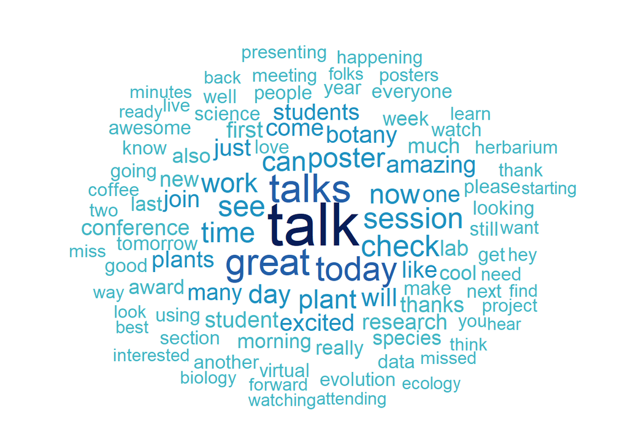

## Most favorited/retweeted users

### Number of favorites received by users

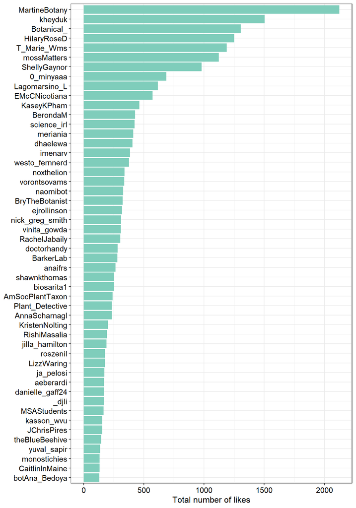

### Number of retweets received by users

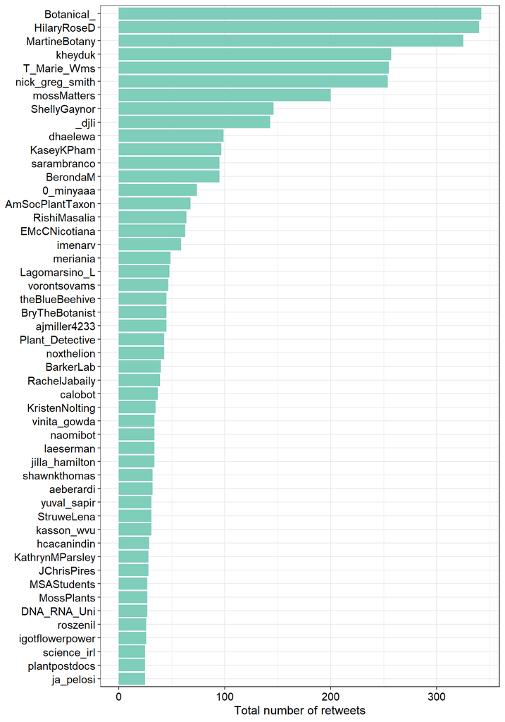

### Mean numbers of likes received

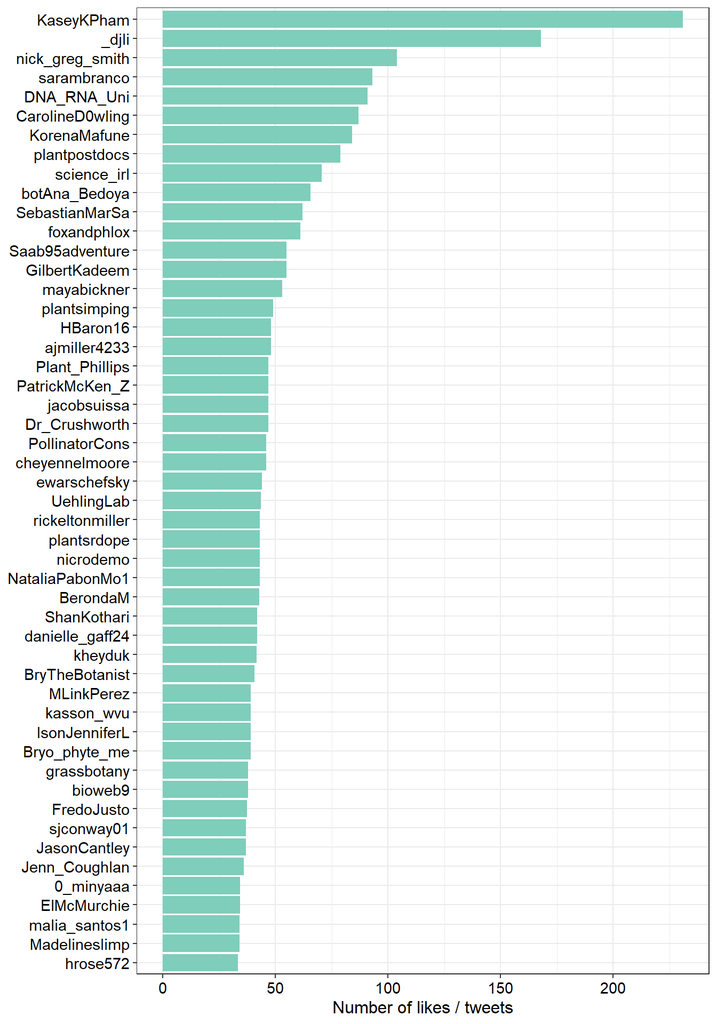

### Mean numbers of retweets received

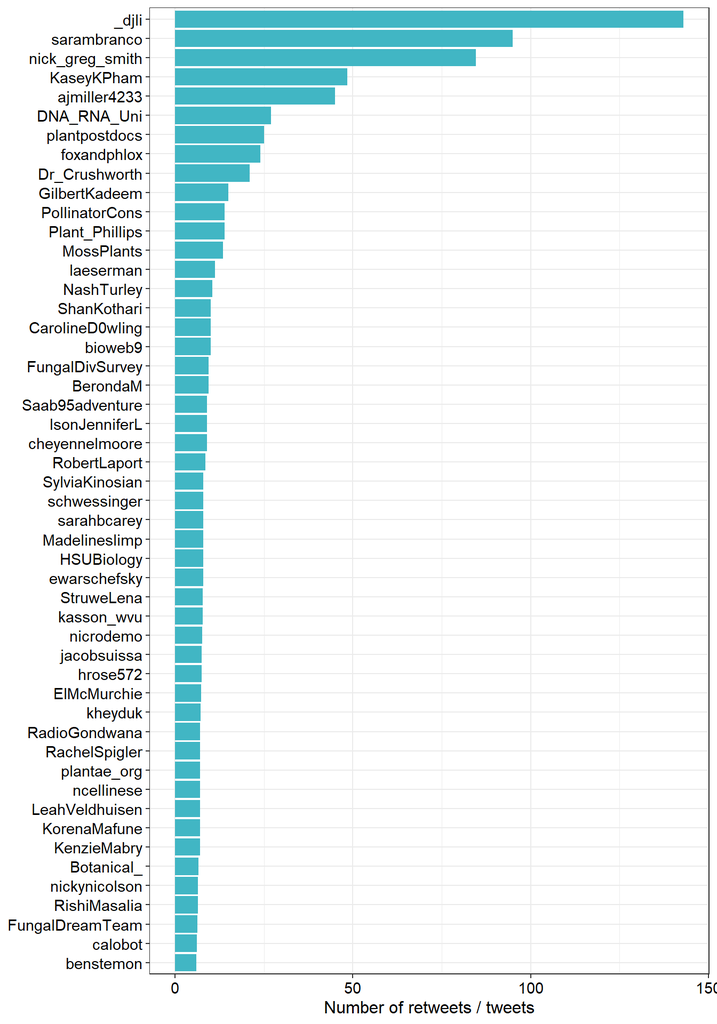

## 🐈

Quite a few cats attended #Botany2021 - [click here for the cat parade](https://erollinson.github.io/Botany2021Cats)

## Data Tables

Data tables for the figures above.

### Top tweeters, excluding retweets

| screen_name | Original |
| --- | --- |
| HilaryRoseD | 91 |
| MartineBotany | 85 |
| mossMatters | 83 |
| vinita_gowda | 68 |
| T_Marie_Wms | 57 |
| Botanical_ | 52 |
| ShellyGaynor | 48 |
| westo_fernnerd | 37 |
| kheyduk | 36 |
| doctorhandy | 32 |

[output cut: 40 more lines]

### Top tweeters, including retweets

| screen_name | total_tweets | Original | Retweets |
| --- | --- | --- | --- |
| MartineBotany | 287 | 85 | 202 |
| JChrisPires | 257 | 11 | 246 |
| shawnkthomas | 256 | 26 | 230 |
| vinita_gowda | 238 | 68 | 170 |
| ShellyGaynor | 163 | 48 | 115 |
| EMcCNicotiana | 137 | 23 | 114 |
| mossMatters | 126 | 83 | 43 |
| AEMcP | 121 | 10 | 111 |
| T_Marie_Wms | 112 | 57 | 55 |
| HilaryRoseD | 99 | 91 | 8 |

[output cut: 40 more lines]

### Corpus (Word cloud)

| word | freq |
| --- | --- |
| talk | 396 |
| talks | 223 |
| great | 206 |
| today | 174 |
| check | 142 |
| session | 138 |
| see | 135 |
| time | 128 |
| now | 125 |
| poster | 124 |

[output cut: 6404 more lines]

### Number of favorites received by users

| screen_name | n_tweets | n_fav |
| --- | --- | --- |
| MartineBotany | 85 | 2123 |
| kheyduk | 36 | 1504 |
| Botanical_ | 52 | 1306 |
| HilaryRoseD | 91 | 1250 |
| T_Marie_Wms | 57 | 1188 |
| mossMatters | 83 | 1124 |
| ShellyGaynor | 48 | 980 |
| 0_minyaaa | 20 | 687 |
| Lagomarsino_L | 29 | 617 |
| EMcCNicotiana | 23 | 574 |

[output cut: 40 more lines]

### Number of retweets received by users

| screen_name | n_tweets | n_rt |
| --- | --- | --- |
| Botanical_ | 52 | 342 |
| HilaryRoseD | 91 | 340 |
| MartineBotany | 85 | 325 |
| kheyduk | 36 | 257 |
| T_Marie_Wms | 57 | 255 |
| nick_greg_smith | 3 | 254 |
| mossMatters | 83 | 200 |
| ShellyGaynor | 48 | 146 |
| _djli | 1 | 143 |
| dhaelewa | 20 | 99 |

[output cut: 40 more lines]

### Mean numbers of likes received

| screen_name | n_tweets | mean_fav |
| --- | --- | --- |
| KaseyKPham | 2 | 231 |
| _djli | 1 | 168 |
| nick_greg_smith | 3 | 104 |
| sarambranco | 1 | 93 |
| DNA_RNA_Uni | 1 | 91 |
| CarolineD0wling | 1 | 87 |
| KorenaMafune | 1 | 84 |
| plantpostdocs | 1 | 79 |
| science_irl | 6 | 70 |
| botAna_Bedoya | 2 | 65 |

[output cut: 40 more lines]

### Mean numbers of retweets received

| screen_name | n_tweets | mean_rt |
| --- | --- | --- |
| _djli | 1 | 143 |
| sarambranco | 1 | 95 |
| nick_greg_smith | 3 | 84 |
| KaseyKPham | 2 | 48 |
| ajmiller4233 | 1 | 45 |
| DNA_RNA_Uni | 1 | 27 |
| plantpostdocs | 1 | 25 |
| foxandphlox | 1 | 24 |
| Dr_Crushworth | 1 | 21 |
| GilbertKadeem | 1 | 15 |

[output cut: 40 more lines]

To the extent possible under law, [Emily J. Rollinson](https://github.com/erollinson/erollinson.github.io) has waived all copyright and related or neighboring rights to Summary of tweets at Botany 2021. This work is published from: United States.